# R

# Functions

1. Creat a new script for your function or codes.
2. Save the script named as “XXX.R” and use source( ) to run the code.
3. Remember to use print( ) or cat( ) so that your final answer will be shown.

```r
x <- c(0.8933, 0.2344, 0.0764, 0.7736)
x.percent <- round(100*x, digits = 1)
x.show <- paste(x.percent, "%", sep = "")
print(x.show)
```

```
## [1] "89.3%" "23.4%" "7.6%"  "77.4%"
```

```r
cat(x.show)
```

```
## 89.3% 23.4% 7.6% 77.4%
```

```r
#Find all perfect numbers smaller than 100. Show the results by print( ).
k <- 1
while(k < 100){
fac <- c()
for(j in 1:k){
if((k %% j) == 0) fac <- c(fac, j)
}
if(k == sum(fac[-length(fac)])){
out <- paste(paste(k, "=", sep=" "),
paste(fac[-length(fac)], collapse = " + "),
sep = " ")
print(out)
}
k <- k+1
}
```

```
## [1] "6 = 1 + 2 + 3"
## [1] "28 = 1 + 2 + 4 + 7 + 14"
```

### function()

```r
f <- function(x){
3*x + 2
}
f(2); f(3); f(4)
```

```
## [1] 8
```

```
## [1] 11
```

```
## [1] 14
```

```r
make.percent <- function(x){
x.percent <- round(100*x, digits = 1)
x.show <- paste(x.percent, "%", sep = "")
cat(x.show)
}
make.percent(c(0.8933, 0.2344, 0.0764, 0.7736))
```

```
## 89.3% 23.4% 7.6% 77.4%
```

```r
#You must tell what will be return when you use the function by return( ) or invisible( ). If you don’t put return( ) at the end of the function, it will treat the last line as the result automatically.
f <- function(x){
return(3*x + 2)
}
f(2)
```

```
## [1] 8
```

### Use function() with multiple input variables

```r
f <- function(x, y){
x^2 + y^2
}
f(2, 2); f(2, 3); f(2, 4)
```

```
## [1] 8
```

```
## [1] 13
```

```
## [1] 20
```

```r
make.percent <- function(x, x.digits){
x.percent <- round(100*x, digits = x.digits)
x.show <- paste(x.percent, "%", sep = "")
return(x.show)
}
make.percent(c(0.8933, 0.2344, 0.0764, 0.7736), 0)
```

```
## [1] "89%" "23%" "8%"  "77%"
```

### Use function() and return multiple output

```r
#Introuction to list( )
X <- list(a = 3, b = c(1,2,3,4,5), c = c("A", "B"))
X
```

```
## $a
## [1] 3
##
## $b
## [1] 1 2 3 4 5
##
## $c
## [1] "A" "B"
```

```r
#Extract an element from a list
X <- list(a = 3, b = c(1,2,3,4,5), c = c("A", "B"))
X$a
```

```
## [1] 3
```

```r
X[[2]]
```

```
## [1] 1 2 3 4 5
```

```r
X[["c"]]
```

```
## [1] "A" "B"
```

```r
#Use function( ) and list( )
#Example: perfect number
perfect.number <- function(a, b){
k <- a
res <- c()
ans <- list()
while(k < b){
fac <- c()
for(j in 1:k){
if((k %% j) == 0) fac <- c(fac, j)
}
if(k == sum(fac[-length(fac)])) {
res <- c(res, k)
ans[[paste(k)]] <- fac[-length(fac)]
}
k <- k+1
}
ans$number <- res
return(ans)
}
#Use invisible( ) to hide some output
perfect.number <- function(a, b){
k <- a
res <- c()
ans <- list()
while(k < b){
fac <- c()
for(j in 1:k){
if((k %% j) == 0) fac <- c(fac, j)
}
if(k == sum(fac[-length(fac)])) {
res <- c(res, k)
ans[[paste(k)]] <- fac[-length(fac)]
}
k <- k+1
}
print(res)
ans$number <- res
return(invisible(ans))
}
```

# Data frame

- Most data sets are stored in R as data frames.
- These are like matrices, but with the columns having their own names.
- Columns can be of different types from each other.

```r
colors <- c("red", "yellow", "blue")
numbers <- c(1, 2, 3)
colors.and.numbers <- data.frame(colors, numbers,
more.numbers = c(4, 5, 6))
colors.and.numbers
```

```
##   colors numbers more.numbers
## 1    red       1            4
## 2 yellow       2            5
## 3   blue       3            6
```

```r
str(colors.and.numbers)
```

```
## 'data.frame':    3 obs. of  3 variables:
##  $ colors      : chr  "red" "yellow" "blue"
##  $ numbers     : num  1 2 3
##  $ more.numbers: num  4 5 6
```

```r
#Types in a data frame: character
colors <- c("red", "yellow", "blue")
numbers <- c(1, 2, 3)
colors.and.numbers <- data.frame(colors, numbers,
more.numbers = c(4, 5, 6),
stringsAsFactors = FALSE)
str(colors.and.numbers)
```

```
## 'data.frame':    3 obs. of  3 variables:
##  $ colors      : chr  "red" "yellow" "blue"
##  $ numbers     : num  1 2 3
##  $ more.numbers: num  4 5 6
```

```r
#Add column and row vectors into a data frame
data1 <- data.frame(colors, numbers, more.numbers = c(4, 5, 6))
data1 <- rbind(data1, c("black", 3, 5))
data1
```

```
##   colors numbers more.numbers
## 1    red       1            4
## 2 yellow       2            5
## 3   blue       3            6
## 4  black       3            5
```

```r
#More on data.frame(): add columns
colors <- c("red", "yellow", "blue")
number1 <- c(1, 2, 3)
number2 <- c(10, 11, 12)
colors.and.numbers <- data.frame(colors, number1) ## construct data.frame
colors.and.numbers$more.numbers <- c(4, 5, 6) ## add one column
colors.and.numbers <- cbind(colors.and.numbers, number2) ## add one column
colors.and.numbers
```

```
##   colors number1 more.numbers number2
## 1    red       1            4      10
## 2 yellow       2            5      11
## 3   blue       3            6      12
```

# Graphics

Given an arbitray vector x:  
1. Histogram: hist(x)  
2. Boxplot: boxplot(x)  
3. Density plot: plot(density(x))

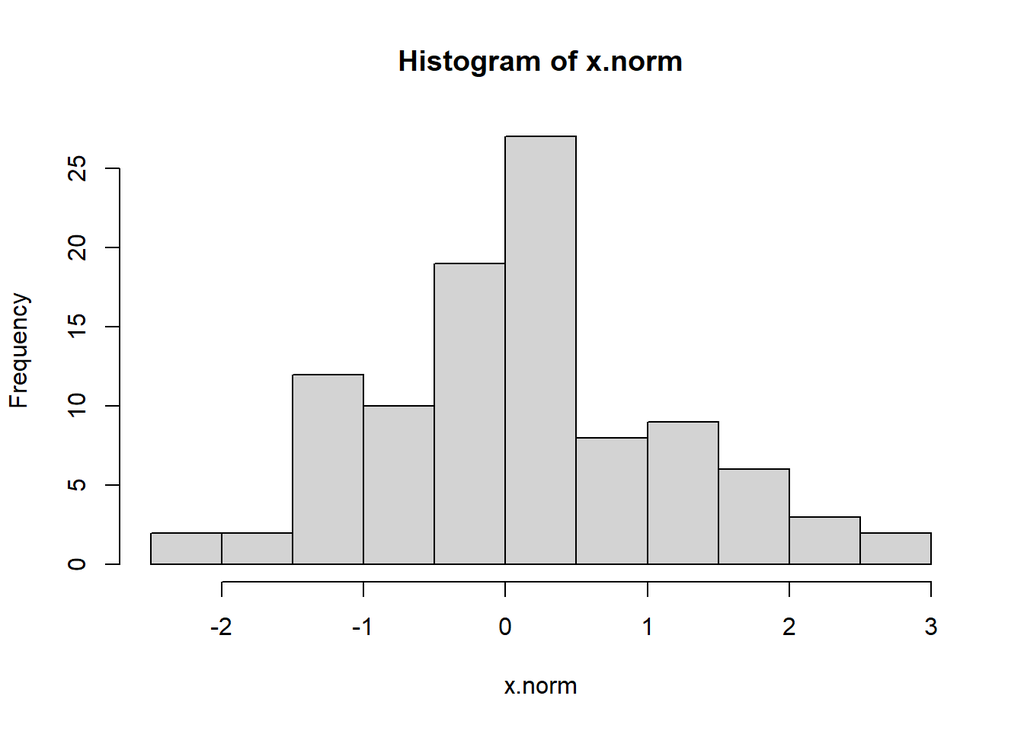

```r
x.norm <- rnorm(100, mean=0, sd=1)
hist(x.norm)
```

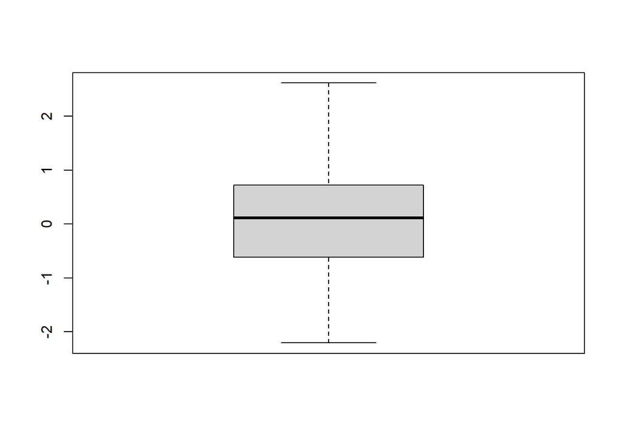

```r
boxplot(x.norm)
```

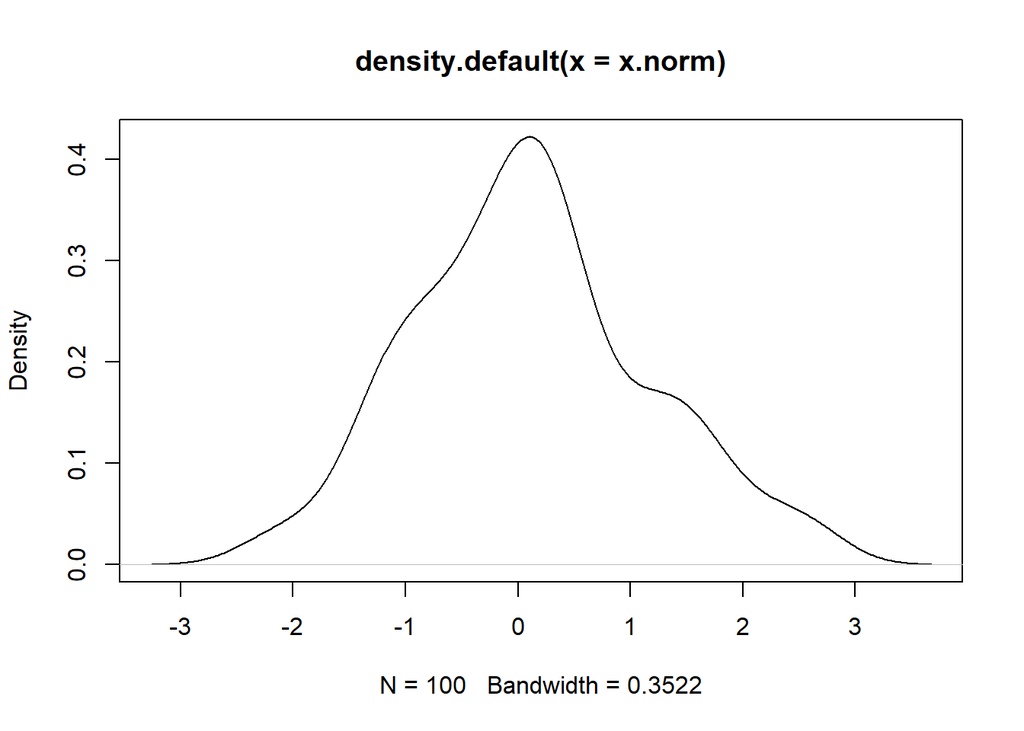

```r
plot(density(x.norm))
```

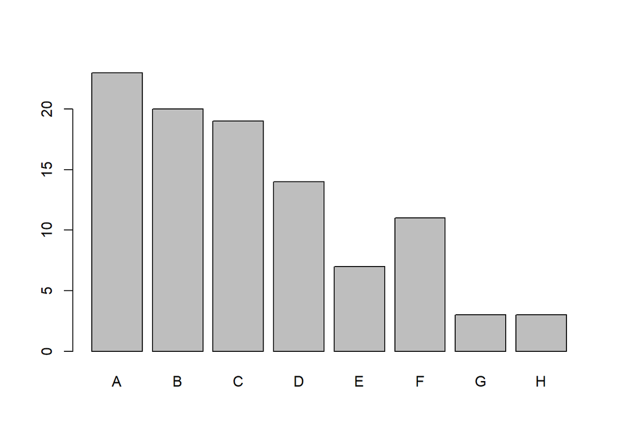

```r
x <- sample(c(1:8), 100, replace=TRUE, prob=c(8:1))
x <- table(x)
names(x) <- c("A", "B", "C", "D", "E", "F", "G", "H")
barplot(x)
```

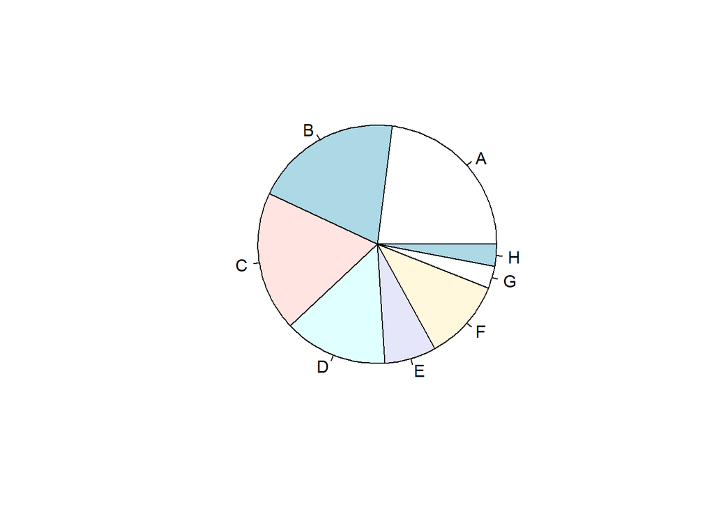

```r
pie(x)
```

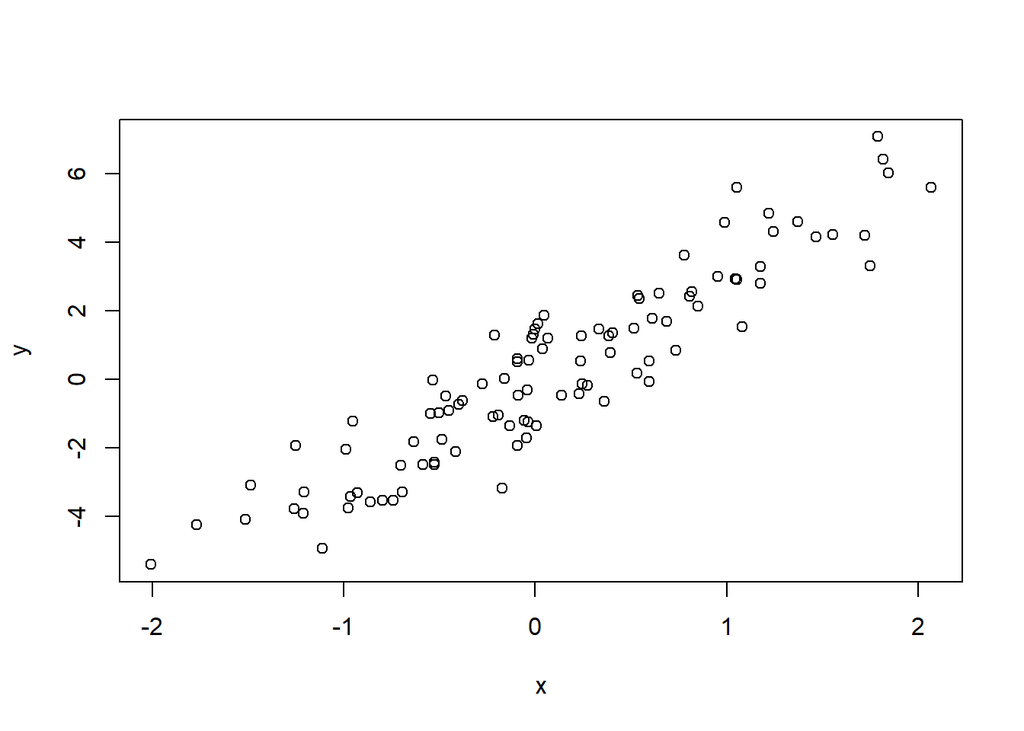

```r
#Scatter plot is for the correlation between two variables
x <- rnorm(100)
y <- 3*x + rnorm(100, 0, 1)
plot(x, y)
```

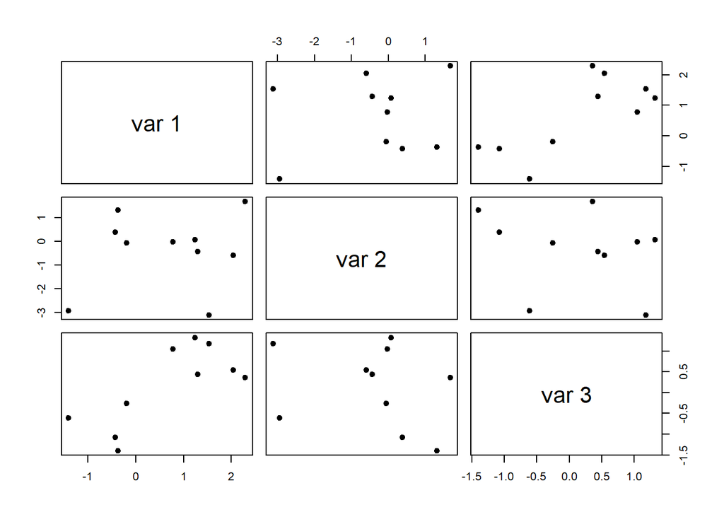

```r
X <- matrix(rnorm(30), 10, 3) ## use matrix
pairs(X, pch = 19)
```

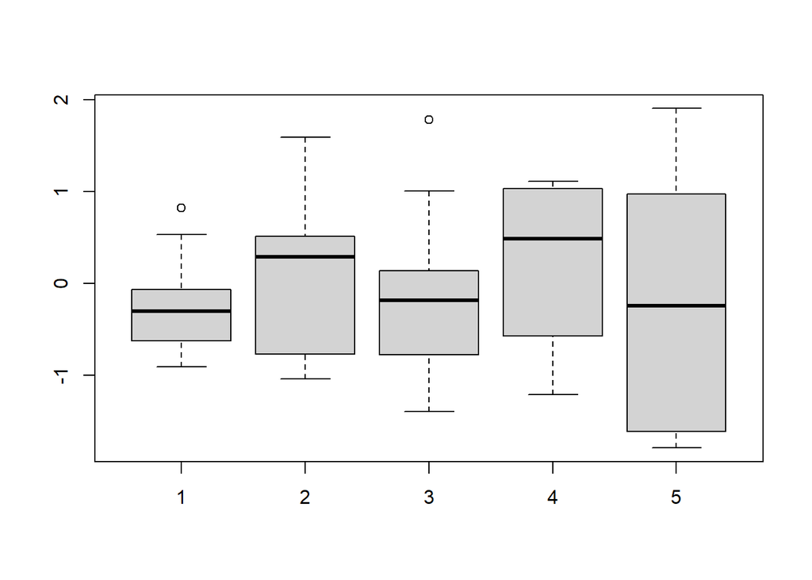

```r
X <- matrix(rnorm(50), 10, 5) ## use matrix
boxplot(X)
```

### Create a plot region with specifical items

plot(x, y,  
type = “p”, # types of the plot  
pch = , # the symbol in the plot  
main = NULL, # the title of the plot  
lty = , # the style of a line  
lwd = , # the width of a line  
cex = , # the size of an text  
bty=“o”, # the box around the plot  
col = , # the color of an object  
xlim = NULL, ylim = NULL, # the range of an axis  
sub = NULL, # the sub-title of the plot  
xlab = NULL, ylab = NULL, # the name of an axis  
cex.main = # the size of the title  
)

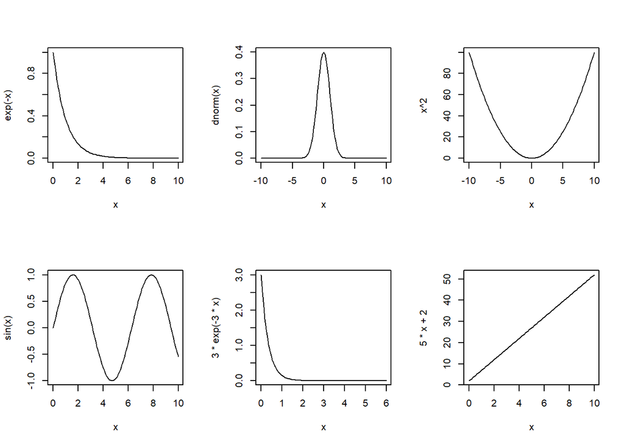

```r
#curve(. . . )
par(mfrow = c(2, 3))
curve(exp(-x), 0, 10)
curve(dnorm(x), -10, 10)
curve(x^2, -10, 10)
curve(sin, 0, 10)
curve(3*exp(-3*x), 0, 6)
curve(5*x+2, 0, 10)
```

### Add points or lines to an existing plot

- points(. . . ): add points
- lines(. . . ): add lines
- abline(. . . ): add straight lines

### Add text to an existing plot

- text(x, y, labels = . . . )
- legend(x, y, legend, . . . )

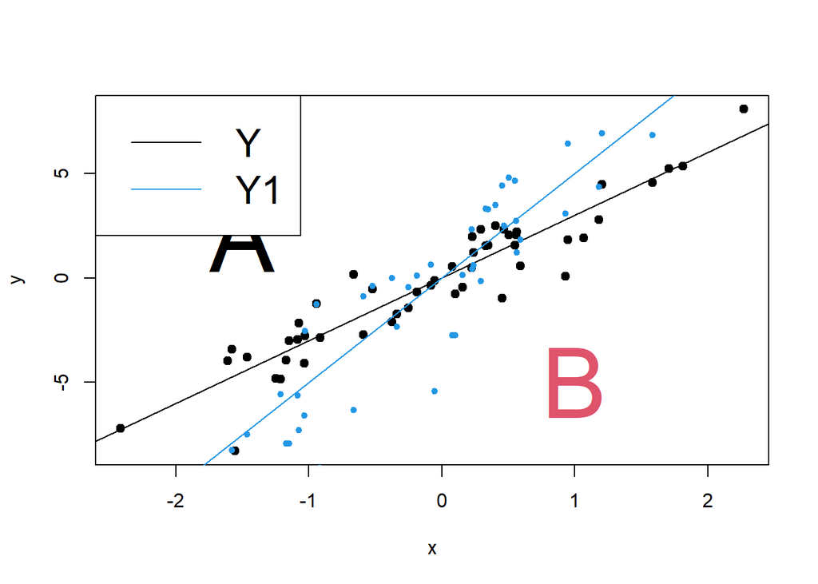

```r
x <- rnorm(50)
y <- 3*x + rnorm(50, 0, 1)
y1 <- 5*x + rnorm(50, 0, 2)
plot(x, y, type = "p", pch = 19)
abline(a = 0, b = 3)
points(x, y1, col = 4, pch = 20)
abline(a = 0, b = 5, col = 4)
text(-1.5, 2, "A", cex = 5)
text(1, -5, "B", cex = 5, col = 2)
legend("topleft", c("Y", "Y1"), col = c(1,4), lty = c(1, 1),
cex = 2)
```

### Re-arrange the region of a figure

Use par(. . . ) to creat an arbitrary region  
1. mfrow = c(2, 2): Define a multi-figure display by row  
2. mfcol = c(2, 2): Define a multi-figure display by column  
3. mai, mar = c(3, 3, 1, 1): The four margin sizes, in inches (mai), or in text line units (mar).  
Use layout(. . . )  
1. layout(matrix(c(1,2,3,3), 2, 2, byrow=TRUE))

# Rmarkdown

- Compile a single R Markdown document to a report in different formats, such as PDF, HTML, or Word.
- Create notebooks in which you can directly run code chunks interactively.
- Make slides for presentations (HTML5, LaTeX Beamer, or PowerPoint).

### Some basic editings

*italics* and *italics*
**bold** and **bold**
superscript<sup>2</sup>
strikethrough
$A = \pi*r^{2}$
$$B = 2 \pi r$$

### Table

| Table Header | Second Header |
| --- | --- |
| Table Cell | Cell 2 |
| Cell 3 | Cell 4 |

### Inline R codes

`r 2 * 3`

# Apply family

### Function: apply(. . . )

apply(X, MARGIN, FUN, . . . ) Returns a vector or array or list of values obtained by applying a function to margins of an array or a matrix.

```r
A <- matrix(rnorm(1500), 10, 3)
apply(A, 1, sum); rowSums(A)
```

```
##  [1]  1.36810224 -0.06148974 -0.98275669  2.01660021  1.41417131 -1.41664358
##  [7] -3.52293647 -1.08327178  1.15982432  3.50722234
```

```
##  [1]  1.36810224 -0.06148974 -0.98275669  2.01660021  1.41417131 -1.41664358
##  [7] -3.52293647 -1.08327178  1.15982432  3.50722234
```

```r
apply(A, 2, sum); colSums(A)
```

```
## [1] -2.3057707  0.6606774  4.0439154
```

```
## [1] -2.3057707  0.6606774  4.0439154
```

### Function: lapply(. . . )

Returns a list of the same length as X, each element of which is the result of applying FUN to the corresponding element of X.

```r
C <- list(a = 1:10, beta = exp(-3:3))
lapply(C, mean)
```

```
## $a
## [1] 5.5
##
## $beta
## [1] 4.535125
```

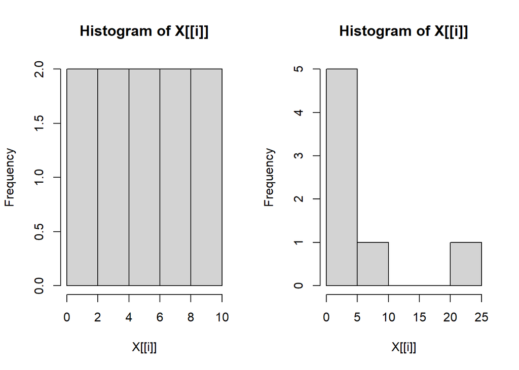

```
## $a
## $breaks
## [1]  0  2  4  6  8 10
##
## $counts
## [1] 2 2 2 2 2
##
## $density
## [1] 0.1 0.1 0.1 0.1 0.1
##
## $mids
## [1] 1 3 5 7 9
##
## $xname
## [1] "X[[i]]"
##
## $equidist
## [1] TRUE
##
## attr(,"class")
## [1] "histogram"
##
## $beta
## $breaks
## [1]  0  5 10 15 20 25
##
## $counts
## [1] 5 1 0 0 1
##
## $density
## [1] 0.14285714 0.02857143 0.00000000 0.00000000 0.02857143
##
## $mids
## [1]  2.5  7.5 12.5 17.5 22.5
##
## $xname
## [1] "X[[i]]"
##
## $equidist
## [1] TRUE
##
## attr(,"class")
## [1] "histogram"
```

```r
par(mfrow = c(1, 2))
lapply(C, hist)
```

### Function: sapply(. . . )

Similarlly to lapply(X, Fun, . . . ) if sapply(x, f, simplify = FALSE, USE.NAMES = FALSE)

```r
sapply(C, summary)
```

```
##             a        beta
## Min.     1.00  0.04978707
## 1st Qu.  3.25  0.25160736
## Median   5.50  1.00000000
## Mean     5.50  4.53512523
## 3rd Qu.  7.75  5.05366896
## Max.    10.00 20.08553692
```

```r
sapply(C, summary, simplify = FALSE)
```

```
## $a
##    Min. 1st Qu.  Median    Mean 3rd Qu.    Max.
##    1.00    3.25    5.50    5.50    7.75   10.00
##
## $beta
##     Min.  1st Qu.   Median     Mean  3rd Qu.     Max.
##  0.04979  0.25161  1.00000  4.53512  5.05367 20.08554
```